# Simple Regression Analysis on Fuel Economy dataset

Ashish S Shanbhag

The datasets contain different estimates of fuel economy for passenger cars and trucks. For each vehicle, various characteristics are recorded such as the engine displacement or number of cylinders. Along with these values, laboratory measurements are made for the city and highway fuel economy (FE) of the car.

This project explains as to how Fuel Efficiency is dependent on Engine Displacement.

Step 1 : Load the given dataset.

```r
library(readr)
FE2010 <- read_csv("FE2010.csv")
```

Step 2 : Perform linear regression.

```r
library(knitr)
model<-lm(FE2010$`Fuel efficiency(Y)` ~ FE2010$`EngDisplacement(X)`)
model
```

```
##
## Call:
## lm(formula = FE2010$`Fuel efficiency(Y)` ~ FE2010$`EngDisplacement(X)`)
##
## Coefficients:
##                 (Intercept)  FE2010$`EngDisplacement(X)`
##                      50.563                       -4.521
```

here are two co-efficients one is intercept and one more is regression co-efficient named engine displacement(x).

Let us name intercept as b0 and regresion co-efficient as b1.

The calculations are explained below

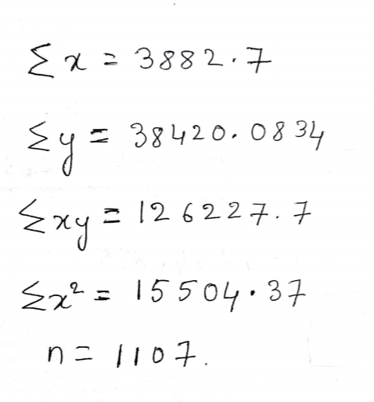

the above values are computed in the file FE2010.xlsx can be found in my GitHub.

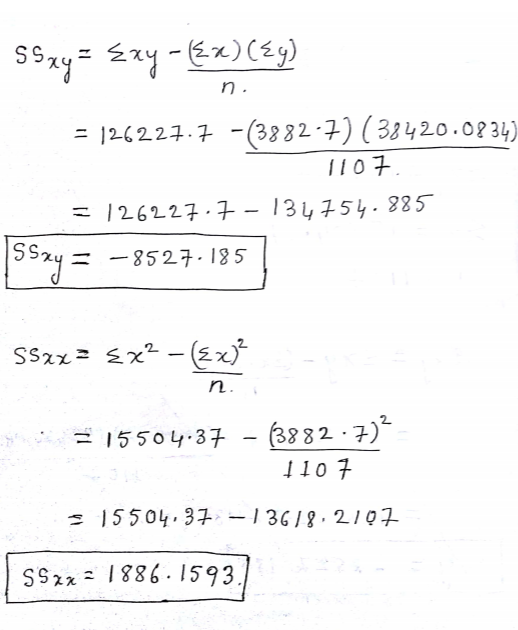

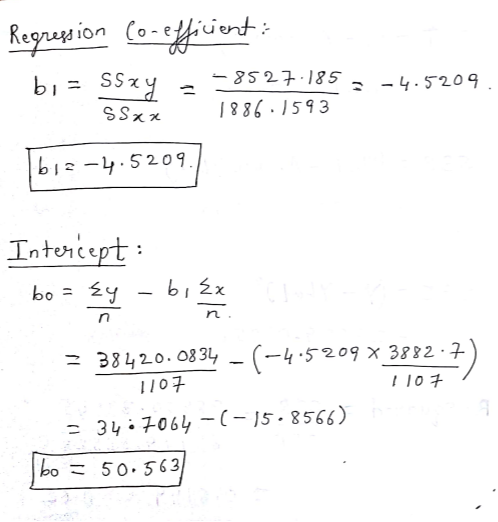

The detailed calculations are found in FE2010.xlsx in my GitHub

Step 3 : Plot the linear model.

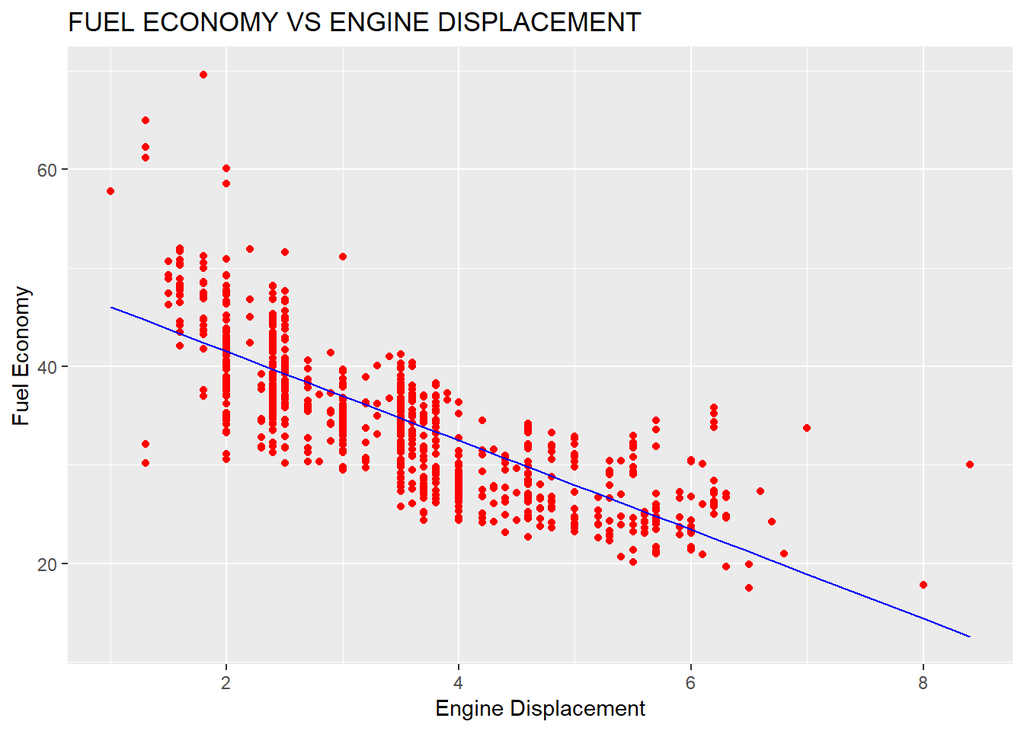

```r
library("ggplot2")
ggplot() +
  geom_point(aes(x=FE2010$`EngDisplacement(X)`,y=FE2010$`Fuel efficiency(Y)`),colour='red')+
  geom_line(aes(x=FE2010$`EngDisplacement(X)`,y=predict(model,newdata = FE2010)),colour='blue')+
  ggtitle('FUEL ECONOMY VS ENGINE DISPLACEMENT')+
  xlab('Engine Displacement')+ylab('Fuel Economy')
```

Now we have to substitute b0 and b1 in regression equation

y=a+bX

y=b0+b1X

Fuel Efficiency = 50.563 - 4.5209 * EngineDisplacement

Step 4 : Now plot the summary of the model

```r
summary(model)
```

```
##
## Call:
## lm(formula = FE2010$`Fuel efficiency(Y)` ~ FE2010$`EngDisplacement(X)`)
##
## Residuals:
##     Min      1Q  Median      3Q     Max
## -14.486  -3.192  -0.365   2.671  27.215
##
## Coefficients:
##                             Estimate Std. Error t value Pr(>|t|)
## (Intercept)                  50.5632     0.3985  126.89   <2e-16 ***
## FE2010$`EngDisplacement(X)`  -4.5209     0.1065  -42.46   <2e-16 ***
## ---
## Signif. codes:  0 '***' 0.001 '**' 0.01 '*' 0.05 '.' 0.1 ' ' 1
##
## Residual standard error: 4.624 on 1105 degrees of freedom
## Multiple R-squared:   0.62,  Adjusted R-squared:  0.6196
## F-statistic:  1803 on 1 and 1105 DF,  p-value: < 2.2e-16
```

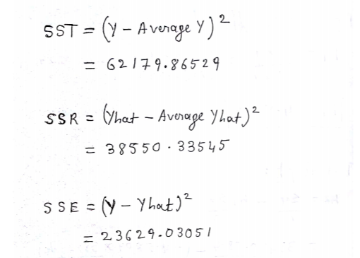

SST stands for Sum Squared Total. SSR stands for Sum Squared Regressor. SSE stands for Sum Squared Error.

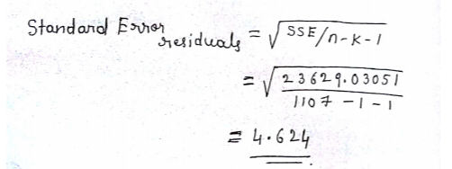

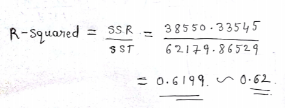